# Midterm_BANA7038001_DATA ANALY METH

#### Data visualization

##### Goal: To show the pairwise plots among variables in the dataset in order to understand relation among the variables.

```
##    aircraft      duration         no_pasg       speed_ground
##  airbus:394   Min.   : 41.95   Min.   :29.00   Min.   : 33.57
##  boeing:387   1st Qu.:119.63   1st Qu.:55.00   1st Qu.: 66.19
##               Median :154.28   Median :60.00   Median : 79.79
##               Mean   :154.78   Mean   :60.08   Mean   : 79.64
##               3rd Qu.:189.66   3rd Qu.:65.00   3rd Qu.: 92.13
##               Max.   :305.62   Max.   :87.00   Max.   :132.78
##    speed_air          height           pitch          distance
##  Min.   : 43.97   Min.   : 6.228   Min.   :2.284   Min.   :  41.72
##  1st Qu.: 70.07   1st Qu.:23.594   1st Qu.:3.653   1st Qu.: 919.05
##  Median : 81.52   Median :30.217   Median :4.014   Median :1273.66
##  Mean   : 81.90   Mean   :30.455   Mean   :4.014   Mean   :1541.20
##  3rd Qu.: 92.43   3rd Qu.:36.988   3rd Qu.:4.382   3rd Qu.:1960.43
##  Max.   :132.91   Max.   :59.946   Max.   :5.927   Max.   :5381.96
##  aircraft_make
##  Min.   :0.0000
##  1st Qu.:0.0000
##  Median :0.0000
##  Mean   :0.4955
##  3rd Qu.:1.0000
##  Max.   :1.0000
```

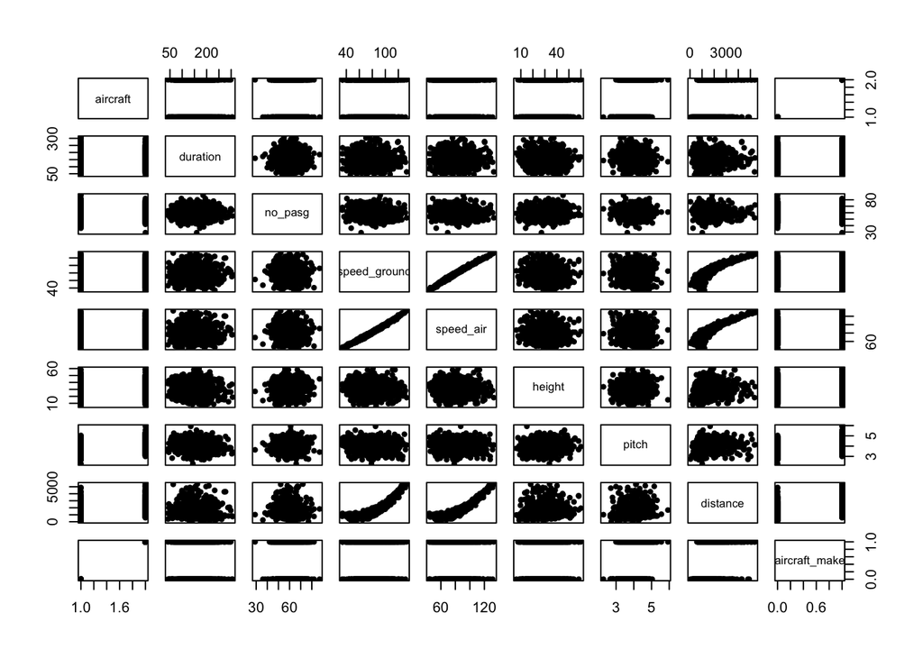

##### Observations:

From the pairwise relation among the variables in the dataset, there is linear relationship between speed_ground and speed_air and between distance and speed_air & speed_ground, it is non linear relationship among them. For aircraft make and distance, it is constant relation.

##### Conclusion/decision:

Lets proceed to Modeling with all covariates.Analyse from the model.In order to predict the relations, Need to find the correlation among the variables. Find the Variance Inflation Factor to know which is contributing more towards VIF.